# Homework 9 - SDS 315

Aggie Angeles

2024-04-17

## *Problem 1*

### *Part A*

The proportion of those receiving a GOTV call who voted in 1998 is 64.8%. The proportion of those not receiving a GOTV call who voted in 1998 is 44.4%.

In our 95% confidence interval for the difference in those who voted in 1998 based on whether they received a GOTV call or not was somewhere between -26.59% and -14.11%. So there is a small amount of uncertainty. The p-value is 3.122e-10, indicating that the difference is statistically significant at the .05 level.

### *Part B: CONFOUNDERS*

Age is a confounder because it effects both the treatment: receiving a GOVT call, and the outcome: voting in 1998. For those that received a GOVT call, the average age is about 58.31 years old while the average age for those that did not receive a GOVT call is about 49.43 years old. For those who voted in 1998 the average age is about 58.31 years old while the average age for those that did not receive a GOVT call is about 49.43 years old.

A person’s majority party is a confounder because it effects both the treatment and the outcome. For those receiving the treatment, the proportion of people belonging to a majority party is about 80.16%. Inversely, about 74.45% belonging to a majority party didn’t receive the treatment. In terms of voting in 1998 as the outcome, the proportion of people belonging to a majority party is about 80.2%. Inversely about 70.01% belonged to a majority party.

Whether a person voted in 1996 is a confounder because it effects both the treatment and the outcome. For those receiving the treatment, the proportion of people who voted in 1996 is about 71.26%. Inversely, about 53.01% voted in 1996 didn’t receive the treatment. In terms of voting in 1998 as the outcome, the proportion of people who voted in 1996 is about 76.24%. Inversely about 34.97% voted in 1996.

### *Part C: MATCHED DATA*

After matching we find that the confounders no longer are an issue in out data. The average age whether or not someone received a GOVT call are both about 58 years old. The proportion of people belong to a majority party, whether or not they received a GOVT call are both about 80%. The proportion of people who voted in 1996 is about 71.26% for those who did and did not receive a GOVT call.

Now given our matched data, the proportion of those receiving a GOTV call who voted in 1998 is 64.8%. The sample proportion of those not receiving a GOTV call who voted in 1998 is 57.4%. In this matched dataset our 95% confidence interval for the difference in those who voted in 1998 based on whether they received a GOTV call or not was somewhere between -14.18% and -.56%. The new p-value is 0.0379, still indicating that the difference is statistically significant at the .05 level but of less grandeur than our previously calculated p-value.

## *Problem 2*

### *Part A*

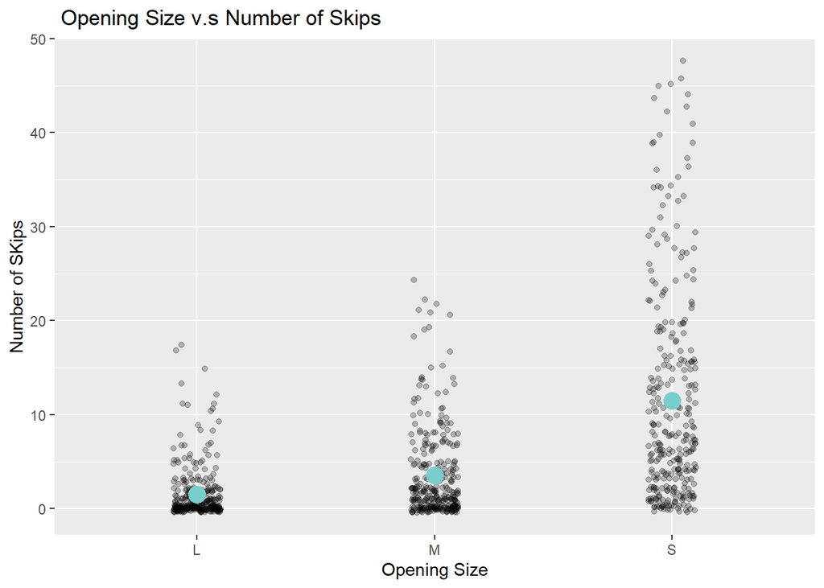

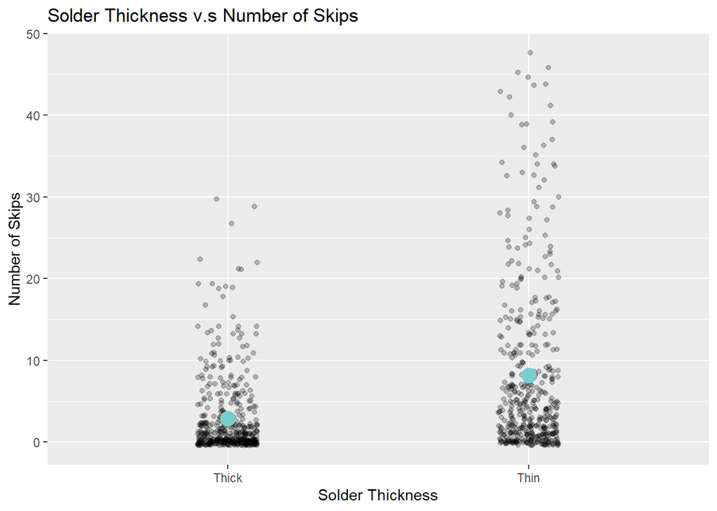

For an opening size that is large, average numbers of skips was 2 (the baseline). For an opening size that is medium, average skips were 2 units higher than large opening sizes. For an opening size that is small, average skips were 9 units higher than large opening sizes.

### *Part B*

95% Large-Sample Confidence Interval for Skips

[output not shown]

### *Part D*

The combination I would recommend is a large opening size with an alloy of thick solder. This combination provided the least amount of skips on average at about .39 skips per alloy type in comparisons to all other estimates.